# K-Means

# Tarea 4.

# Estudiante

- Merian Herrera Fuentes
- meryann68@gmail.com
- 207180364

# Ejercicios

Librerias

**1. Desarolle el Análisis del Problema**

En el siguiente dataset podemos observar datos sobre compras al por mayor de ariculos como comestibles, papel, detergente, productos frescos… tambien, tenemos el medio por el cual fueron adquiridos los productos y la region donde los mismos fueron comprados.

Se desea aplicar un algoritmo k-means para agrupar dichos clientes, esto puede ser de utilidad por ejemplo para identificar grupos de clientes y dirigir campañas de mercadeo a esos sectores en especifico.

**2. Cargue el archivo Wholesale customers data.csv en una variable**

```r
customers <- read_csv('Wholesale.csv')
customers$Region <- as.factor(customers$Region)
customers$Channel <- as.factor(customers$Channel)

head(customers, 500)
```

```
## # A tibble: 440 x 8
##    Channel Region Fresh  Milk Grocery Frozen Detergents_Paper Delicassen
##    <fct>   <fct>  <dbl> <dbl>   <dbl>  <dbl>            <dbl>      <dbl>
##  1 2       3      12669  9656    7561    214             2674       1338
##  2 2       3       7057  9810    9568   1762             3293       1776
##  3 2       3       6353  8808    7684   2405             3516       7844
##  4 1       3      13265  1196    4221   6404              507       1788
##  5 2       3      22615  5410    7198   3915             1777       5185
##  6 2       3       9413  8259    5126    666             1795       1451
##  7 2       3      12126  3199    6975    480             3140        545
##  8 2       3       7579  4956    9426   1669             3321       2566
##  9 1       3       5963  3648    6192    425             1716        750
## 10 2       3       6006 11093   18881   1159             7425       2098
## # ... with 430 more rows
```

**3. Desarolle el Entendimiento de los Datos**

Con el fin de analizar y agrupar los clientes por los productos que consumen, se trabajó con un conjunto de datos que contiene 440 observaciones y 8 variables:

1. FRESH: Consumo anual de productos frescos (continua)

```r
summary(customers$Fresh)
```

```
##    Min. 1st Qu.  Median    Mean 3rd Qu.    Max.
##       3    3128    8504   12000   16934  112151
```

2. MILK: Consumo anual de leche o productos a base de la misma (Continua)

```r
summary(customers$Milk)
```

```
##    Min. 1st Qu.  Median    Mean 3rd Qu.    Max.
##      55    1533    3627    5796    7190   73498
```

3. GROCERY: Consumo anual de comestibles (Continua)

```r
summary(customers$Grocery)
```

```
##    Min. 1st Qu.  Median    Mean 3rd Qu.    Max.
##       3    2153    4756    7951   10656   92780
```

4. FROZEN: Consumo anual de productos congelados (Continua)

```r
summary(customers$Frozen)
```

```
##    Min. 1st Qu.  Median    Mean 3rd Qu.    Max.
##    25.0   742.2  1526.0  3071.9  3554.2 60869.0
```

5. DETERGENTS_PAPER: Consumo anual de detergentes y productos a base de papel (Continua)

```r
summary(customers$Detergents_Paper)
```

```
##    Min. 1st Qu.  Median    Mean 3rd Qu.    Max.
##     3.0   256.8   816.5  2881.5  3922.0 40827.0
```

6. DELICATESSEN: Consumo anual de productos delicassen. (Continua);

```r
summary(customers$Delicassen)
```

```
##    Min. 1st Qu.  Median    Mean 3rd Qu.    Max.
##     3.0   408.2   965.5  1524.9  1820.2 47943.0
```

7. CHANNEL: Canal de consumo (Categorica)
- 1: Horeca (Hotel/Restaurant/Cafe)
- 2: Retail channel

```r
customers %>%
  group_by(Channel) %>%
  summarise(count = n())
```

```
## # A tibble: 2 x 2
##   Channel count
##   <fct>   <int>
## 1 1         298
## 2 2         142
```

8. REGION: Region del cosumidor (Categorica)
- 1: Lisbon
- 2: Porto
- 3: other region

```r
customers %>%
  group_by(Region) %>%
  summarise(count = n())
```

```
## # A tibble: 3 x 2
##   Region count
##   <fct>  <int>
## 1 1         77
## 2 2         47
## 3 3        316
```

Ademas, se puede concluir que no existen valores nulos en el dataset.

```r
sapply(customers, function(x) {sum(is.na(x))})
```

```
##          Channel           Region            Fresh             Milk
##                0                0                0                0
##          Grocery           Frozen Detergents_Paper       Delicassen
##                0                0                0                0
```

Fuente del dataset:  
https://archive.ics.uci.edu/ml/datasets/Wholesale+customers

**Preparacion de los datos**

```r
customers$Fresh <- log(customers$Fresh)
customers$Milk <- log(customers$Milk)
customers$Detergents_Paper <- log(customers$Detergents_Paper)
customers$Grocery <- log(customers$Grocery)
customers$Frozen <- log(customers$Frozen)
customers$Delicassen <- log(customers$Delicassen)
```

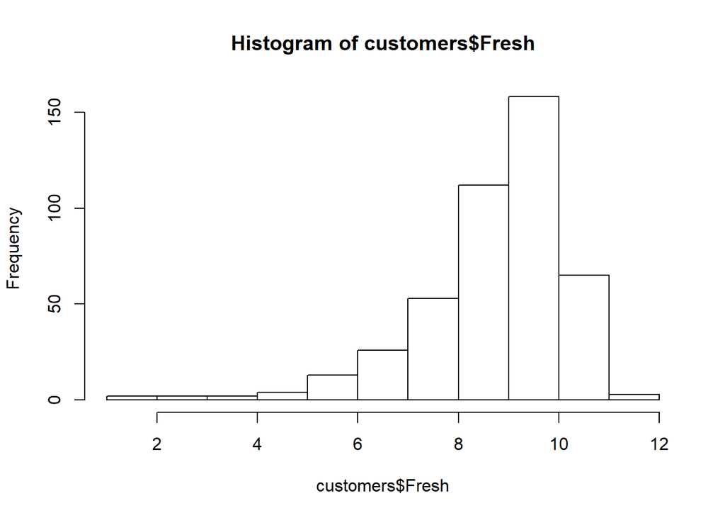

```r
hist(customers$Fresh)
```

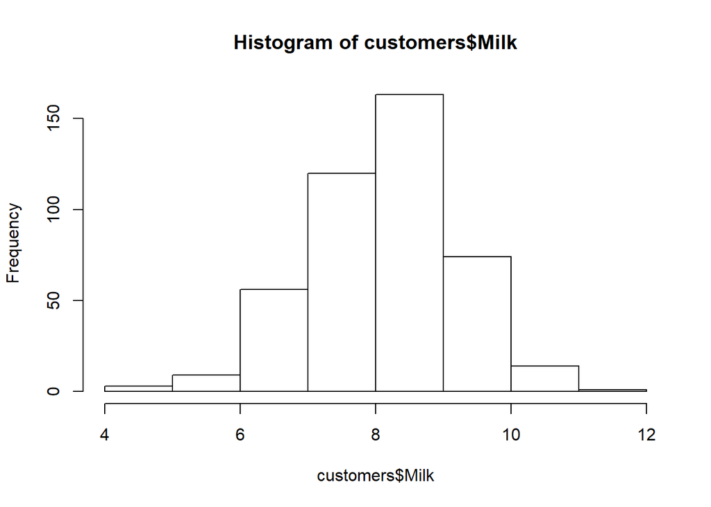

```r
hist(customers$Milk)
```

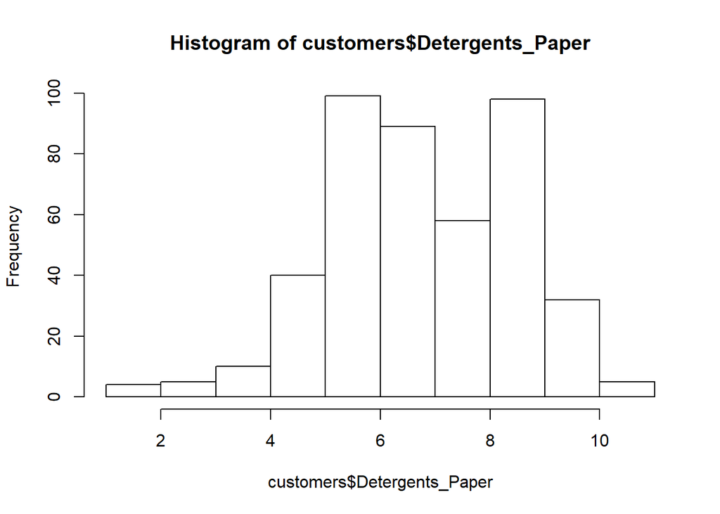

```r
hist(customers$Detergents_Paper)
```

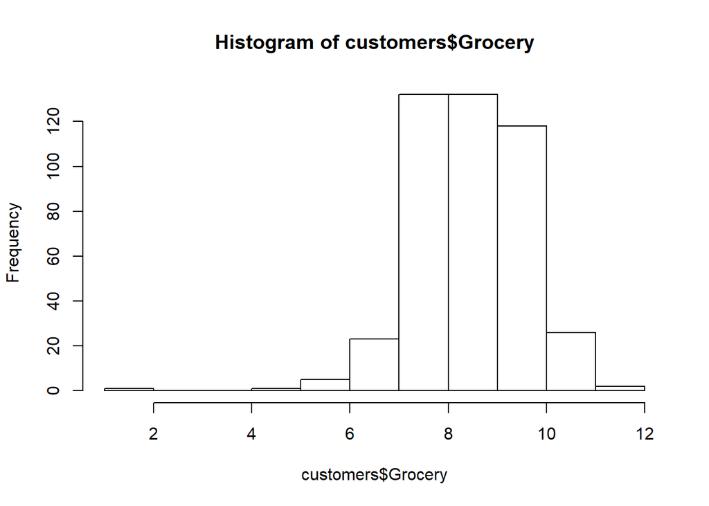

```r
hist(customers$Grocery)
```

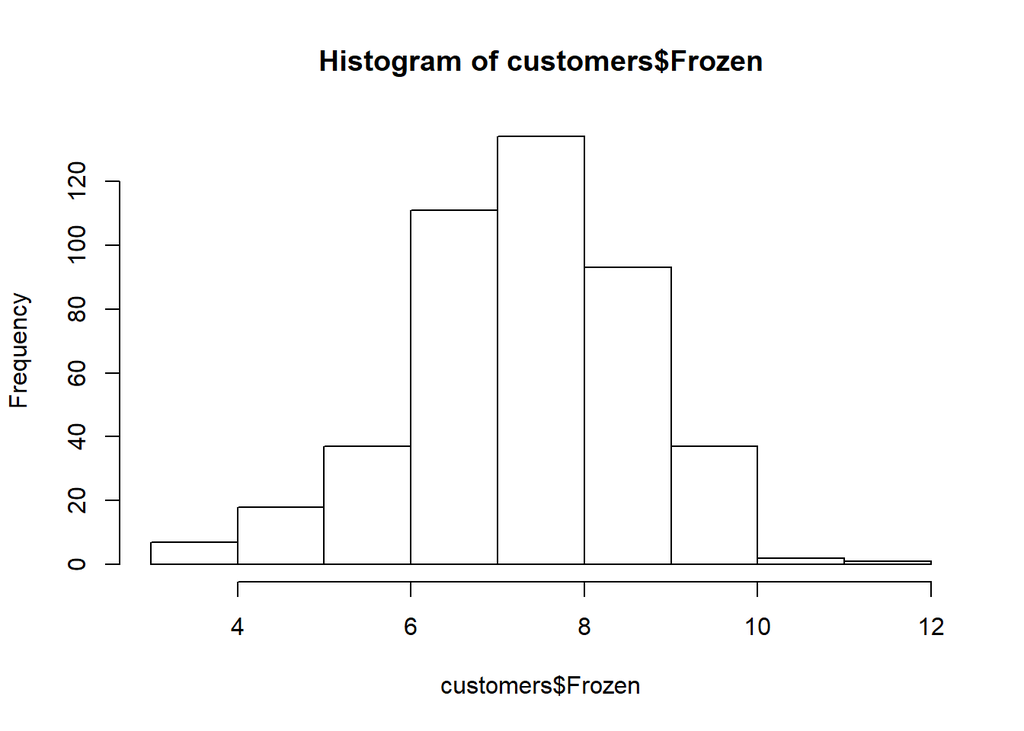

```r
hist(customers$Frozen)
```

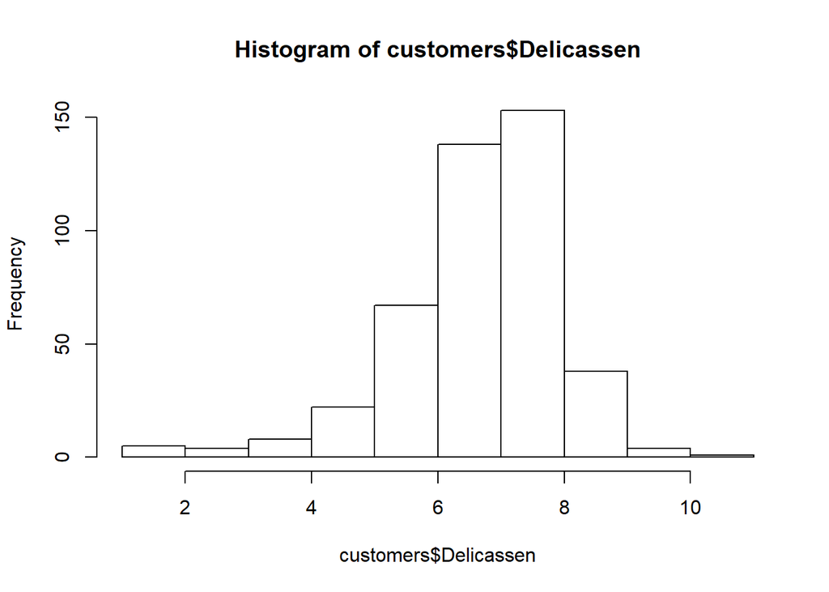

```r
hist(customers$Delicassen)
```

**4. Utilizando barplot cree un gráfico de los atributos del dataset, observe las correlaciones entre atributos**

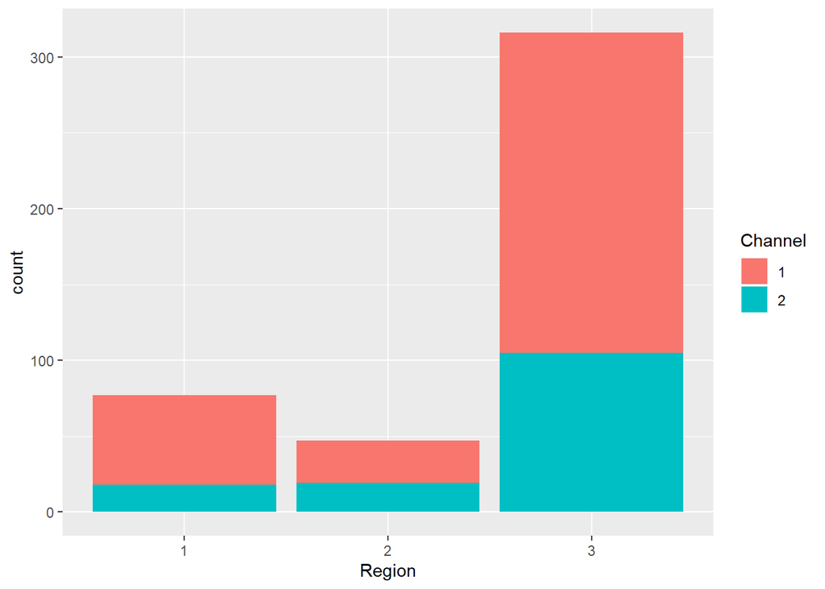

```r
cust_gb <- customers %>%
  group_by(Region, Channel) %>%
  summarise(count = n())

ggplot(data=cust_gb, aes(x=Region, y=count, fill=Channel)) +
  geom_bar(stat="identity")
```

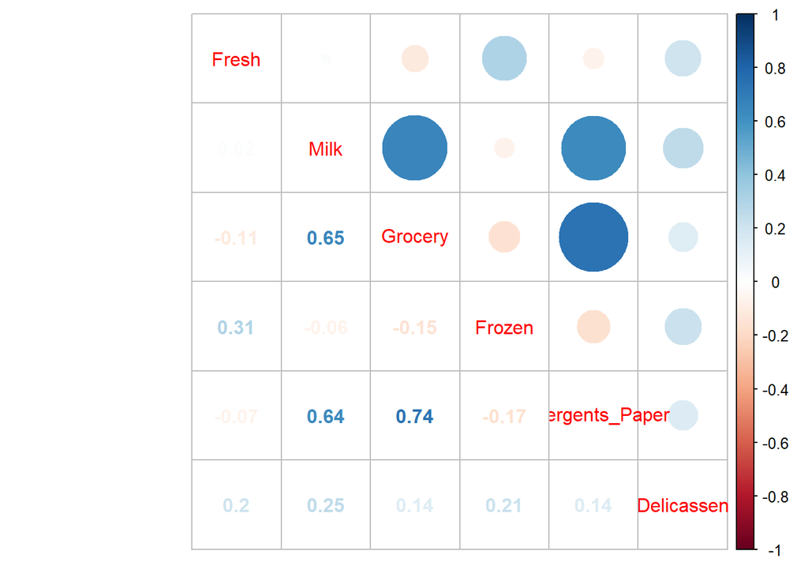

```r
customers  %>%
  select(-c("Channel", "Region")) %>%
  log()  %>%
  cor() %>%
  corrplot.mixed()
```

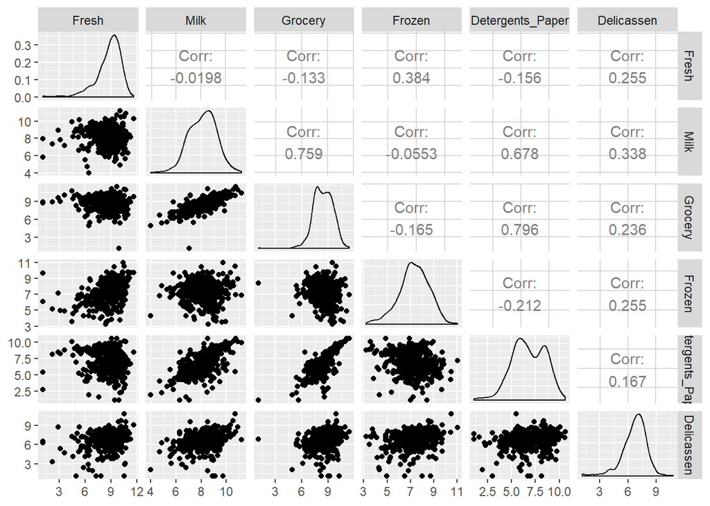

```r
ggpairs(customers,columns = c(3, 4, 5, 6, 7, 8))
```

**5. Explique el siguiente gráfico**

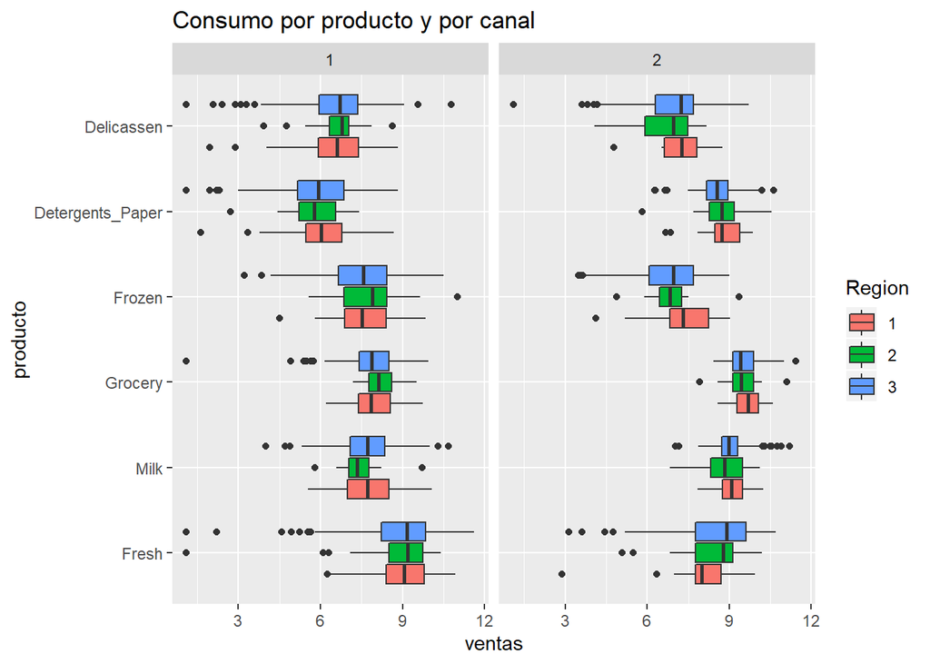

```r
customers_df <- as.data.frame(customers)
customers_melted <- melt(data=customers_df, id.vars = c("Region", "Channel"))

# BoxPlot
bxplt <- ggplot(data = customers_melted, aes(x= variable, y = value, fill=Region))
bxplt <- bxplt + geom_boxplot()
bxplt <- bxplt + facet_wrap(~Channel)
bxplt <- bxplt + coord_flip()
bxplt <- bxplt + labs(x = 'producto', y  = 'ventas')
bxplt <- bxplt + ggtitle('Consumo por producto y por canal')
bxplt
```

Los box plots son graficos usados para representar unicamente variables continuas y en ellos podemos ver la distribucion de nuestros datos y encontrar la mayor concentracion de los mismos, asi como observar la varianza que existe.

Tenemos una representacion por cada producto listado en el dataset, podemos ver los siguientes datos representados en cada una de las figuras:  
* Percentil 25 o cuartil 1: Este esta representado por la linea dibujada del 0 hasta el inicio de la figura de caja.  
* Cuartiles 2 y 3: Estos los vemos representados en la caja, aqui podemos observar la varianza de los datos asi como la mediana.  
* Cuartil 4: Lo vemos representado en la lnea que comienza justo despues de que termina la caja.  
* outliers: Los valores atipicos o expremos los vemos representados por puntos en el grafico.

Con respecto a los datos que vemos representados en el grafico, podemos observar una alta varinza en los datos de la region 1, para el channel 1, mientras que para la region 2 podemos observar que su varianza es menor, lo que las compras realizadas por los clientes de esta region que compran mediante el canal 1 son muy similares.

**6. Cree un modelo de agrupación K- Means**  
Para agrupar a los clientes con base al consumo, vamos a utilizar solo las variables Fresh, Milk, Grocery, Frozen, Detergents_Paper y Delicassen. En este caso, vamos a intentar agrupar los clientes en 5 grupos diferentes.

```r
set.seed(4)

customers_matriz = as.matrix(customers[,c(3:8)])

# 5 Centroides utilizando k-means
modelo.agrupacion <- kmeans(customers_matriz, centers = 5)

# predecir utilizando el modelo para agregar una variable nueva llamada 'cluster' al conjunto de datos
customers$cluster <- modelo.agrupacion$cluster

# convertir la variable nueva a un factor
customers$cluster <- factor(customers$cluster)
```

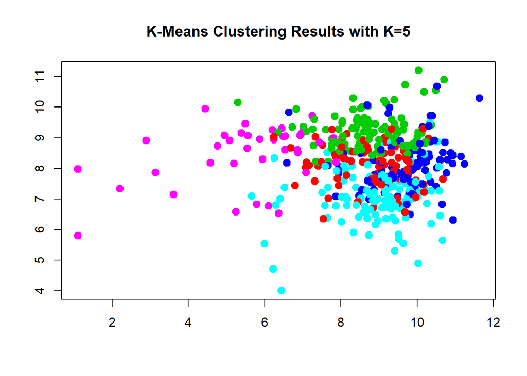

```r
plot(customers_matriz,
     col = (modelo.agrupacion$cluster + 1),
     main = "K-Means Clustering Results with K=5",
     xlab = "",
     ylab = "",
     pch = 20,
     cex = 2)
```

**6. Realice al menos 3 modelos cambiando los centroides**

[figure not shown]

```r
modelo.dos.centroides <- kmeans(customers_matriz, centers = 2)

plot(customers_matriz,
     col = (modelo.dos.centroides$cluster + 1),
     main = "K-Means Clustering Results with K=5",
     xlab = "",
     ylab = "",
     pch = 20,
     cex = 2)
```

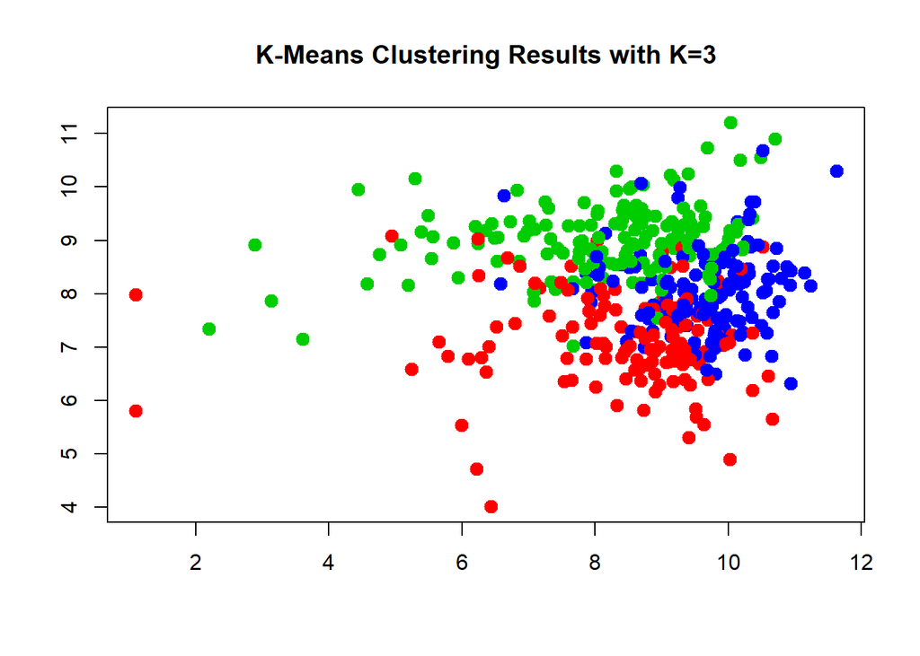

```r
modelo.tres.centroides <- kmeans(customers_matriz, centers = 3)

plot(customers_matriz,
     col = (modelo.tres.centroides$cluster + 1),
     main = "K-Means Clustering Results with K=3",
     xlab = "",
     ylab = "",
     pch = 20,
     cex = 2)
```

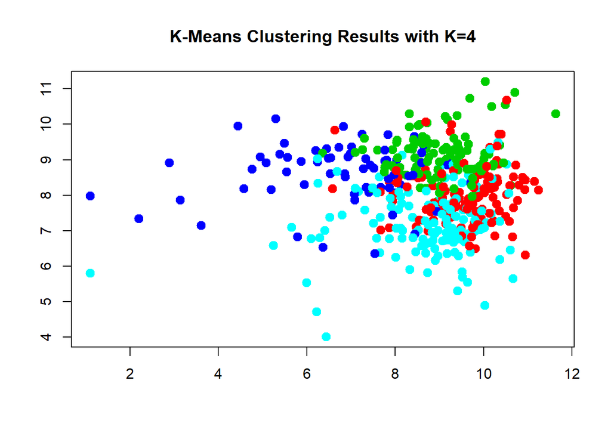

```r
modelo.cuatro.centroides <- kmeans(customers_matriz, centers = 4)

plot(customers_matriz,
     col = (modelo.cuatro.centroides$cluster + 1),
     main = "K-Means Clustering Results with K=4",
     xlab = "",
     ylab = "",
     pch = 20,
     cex = 2)
```

**7. Evaluación del modelo**

```r
#Explicacion Modelo 5 Centroides
by(customers, customers$cluster, summary)
```

```
## customers$cluster: 1
##  Channel Region     Fresh             Milk          Grocery
##  1:65    1:15   Min.   : 6.242   Min.   :6.358   Min.   :6.349
##  2:19    2:10   1st Qu.: 8.037   1st Qu.:7.649   1st Qu.:7.935
##          3:59   Median : 9.044   Median :8.153   Median :8.421
##                 Mean   : 8.815   Mean   :8.078   Mean   :8.371
##                 3rd Qu.: 9.503   3rd Qu.:8.514   3rd Qu.:8.839
##                 Max.   :10.671   Max.   :9.306   Max.   :9.739
##      Frozen      Detergents_Paper   Delicassen    cluster
##  Min.   :3.850   Min.   :4.431    Min.   :3.584   1:84
##  1st Qu.:6.026   1st Qu.:6.393    1st Qu.:5.702   2: 0
##  Median :6.493   Median :6.998    Median :6.328   3: 0
##  Mean   :6.414   Mean   :6.961    Mean   :6.316   4: 0
##  3rd Qu.:7.053   3rd Qu.:7.595    3rd Qu.:7.118   5: 0
##  Max.   :8.372   Max.   :8.839    Max.   :8.482
## --------------------------------------------------------
## customers$cluster: 2
##  Channel Region     Fresh             Milk           Grocery
##  1: 9    1:17   Min.   : 5.298   Min.   : 8.191   Min.   : 8.672
##  2:95    2:13   1st Qu.: 8.048   1st Qu.: 8.755   1st Qu.: 9.256
##          3:74   Median : 8.711   Median : 9.165   Median : 9.499
##                 Mean   : 8.730   Mean   : 9.212   Mean   : 9.612
##                 3rd Qu.: 9.442   3rd Qu.: 9.470   3rd Qu.: 9.941
##                 Max.   :10.702   Max.   :11.205   Max.   :11.438
##      Frozen      Detergents_Paper   Delicassen    cluster
##  Min.   :3.219   Min.   : 7.550   Min.   :4.956   1:  0
##  1st Qu.:6.714   1st Qu.: 8.299   1st Qu.:6.926   2:104
##  Median :7.162   Median : 8.749   Median :7.432   3:  0
##  Mean   :7.007   Mean   : 8.759   Mean   :7.356   4:  0
##  3rd Qu.:7.819   3rd Qu.: 9.099   3rd Qu.:7.796   5:  0
##  Max.   :8.960   Max.   :10.617   Max.   :9.713
## --------------------------------------------------------
## customers$cluster: 3
##  Channel Region     Fresh             Milk           Grocery
##  1:92    1:20   Min.   : 6.575   Min.   : 6.319   Min.   :6.550
##  2: 6    2:12   1st Qu.: 9.127   1st Qu.: 7.551   1st Qu.:7.814
##          3:66   Median : 9.812   Median : 8.087   Median :8.273
##                 Mean   : 9.646   Mean   : 8.127   Mean   :8.287
##                 3rd Qu.:10.230   3rd Qu.: 8.505   3rd Qu.:8.710
##                 Max.   :11.628   Max.   :10.691   Max.   :9.954
```

[output cut: 24 more lines]

```
## customers$cluster: 5
##  Channel Region     Fresh            Milk          Grocery
##  1:15    1: 4   Min.   :1.099   Min.   :5.808   Min.   : 7.607
##  2:22    2: 5   1st Qu.:4.942   1st Qu.:7.979   1st Qu.: 8.857
##          3:28   Median :5.872   Median :8.743   Median : 9.353
##                 Mean   :5.509   Mean   :8.424   Mean   : 9.256
##                 3rd Qu.:6.542   3rd Qu.:9.068   3rd Qu.: 9.832
##                 Max.   :7.863   Max.   :9.950   Max.   :10.733
##      Frozen      Detergents_Paper   Delicassen    cluster
##  Min.   :3.584   Min.   : 2.708   Min.   :1.099   1: 0
##  1st Qu.:5.165   1st Qu.: 7.952   1st Qu.:4.127   2: 0
##  Median :5.996   Median : 8.433   Median :5.557   3: 0
##  Mean   :6.019   Mean   : 8.000   Mean   :5.218   4: 0
##  3rd Qu.:6.683   3rd Qu.: 8.892   3rd Qu.:6.574   5:37
##  Max.   :9.655   Max.   :10.095   Max.   :8.760
```

```r
#Explicacion Modelo 2 Centroides
by(customers, modelo.dos.centroides$cluster, summary)
```

```
## modelo.dos.centroides$cluster: 1
##  Channel Region      Fresh             Milk           Grocery
##  1:252   1: 50   Min.   : 1.099   Min.   : 4.007   Min.   :1.099
##  2:  6   2: 27   1st Qu.: 8.529   1st Qu.: 6.988   1st Qu.:7.402
##          3:181   Median : 9.280   Median : 7.558   Median :7.807
##                  Mean   : 9.062   Mean   : 7.557   Mean   :7.776
##                  3rd Qu.: 9.862   3rd Qu.: 8.190   3rd Qu.:8.278
##                  Max.   :11.242   Max.   :10.691   Max.   :9.912
##      Frozen       Detergents_Paper   Delicassen     cluster
##  Min.   : 3.850   Min.   :1.099    Min.   : 1.099   1: 45
##  1st Qu.: 6.834   1st Qu.:5.119    1st Qu.: 5.979   2:  0
##  Median : 7.745   Median :5.745    Median : 6.707   3: 90
##  Mean   : 7.690   Mean   :5.625    Mean   : 6.557   4:117
##  3rd Qu.: 8.590   3rd Qu.:6.409    3rd Qu.: 7.279   5:  6
##  Max.   :11.016   Max.   :8.468    Max.   :10.778
## --------------------------------------------------------
## modelo.dos.centroides$cluster: 2
##  Channel Region      Fresh             Milk           Grocery
##  1: 46   1: 27   Min.   : 1.099   Min.   : 6.850   Min.   : 7.707
##  2:136   2: 20   1st Qu.: 7.669   1st Qu.: 8.522   1st Qu.: 8.973
##          3:135   Median : 8.595   Median : 8.923   Median : 9.336
##                  Mean   : 8.261   Mean   : 8.921   Mean   : 9.385
##                  3rd Qu.: 9.384   3rd Qu.: 9.314   3rd Qu.: 9.826
##                  Max.   :11.628   Max.   :11.205   Max.   :11.438
##      Frozen      Detergents_Paper   Delicassen    cluster
##  Min.   :3.219   Min.   : 5.407   Min.   :1.099   1: 39
##  1st Qu.:6.011   1st Qu.: 7.932   1st Qu.:6.231   2:104
##  Median :6.898   Median : 8.424   Median :7.161   3:  8
##  Mean   :6.750   Mean   : 8.432   Mean   :6.818   4:  0
##  3rd Qu.:7.525   3rd Qu.: 8.900   3rd Qu.:7.673   5: 31
##  Max.   :9.726   Max.   :10.617   Max.   :9.713
```

```r
#Explicacion Modelo 3 Centroides
by(customers, modelo.tres.centroides$cluster, summary)
```

```
## modelo.tres.centroides$cluster: 1
##  Channel Region     Fresh             Milk          Grocery
##  1:134   1:27   Min.   : 1.099   Min.   :4.007   Min.   :1.099
##  2:  0   2:10   1st Qu.: 7.952   1st Qu.:6.712   1st Qu.:7.122
##          3:97   Median : 8.870   Median :7.072   Median :7.534
##                 Mean   : 8.458   Mean   :7.154   Mean   :7.412
##                 3rd Qu.: 9.344   3rd Qu.:7.702   3rd Qu.:7.957
##                 Max.   :10.664   Max.   :9.088   Max.   :9.022
##      Frozen      Detergents_Paper   Delicassen    cluster
##  Min.   :3.850   Min.   :1.099    Min.   :1.099   1: 26
##  1st Qu.:6.365   1st Qu.:4.483    1st Qu.:5.517   2:  0
##  Median :7.057   Median :5.405    Median :6.017   3:  0
##  Mean   :7.071   Mean   :5.204    Mean   :5.849   4:100
##  3rd Qu.:7.782   3rd Qu.:5.995    3rd Qu.:6.605   5:  8
##  Max.   :9.736   Max.   :8.468    Max.   :7.824
## --------------------------------------------------------
## modelo.tres.centroides$cluster: 2
##  Channel Region      Fresh             Milk           Grocery
##  1: 30   1: 23   Min.   : 2.197   Min.   : 7.017   Min.   : 7.946
##  2:129   2: 19   1st Qu.: 7.442   1st Qu.: 8.610   1st Qu.: 9.086
##          3:117   Median : 8.481   Median : 8.959   Median : 9.400
##                  Mean   : 8.151   Mean   : 8.990   Mean   : 9.461
##                  3rd Qu.: 9.216   3rd Qu.: 9.336   3rd Qu.: 9.885
##                  Max.   :10.702   Max.   :11.205   Max.   :11.438
##      Frozen      Detergents_Paper   Delicassen    cluster
##  Min.   :3.219   Min.   : 6.449   Min.   :1.099   1: 30
##  1st Qu.:5.974   1st Qu.: 8.161   1st Qu.:6.099   2:100
##  Median :6.862   Median : 8.533   Median :7.102   3:  0
##  Mean   :6.677   Mean   : 8.574   Mean   :6.756   4:  0
##  3rd Qu.:7.484   3rd Qu.: 8.968   3rd Qu.:7.566   5: 29
##  Max.   :8.960   Max.   :10.617   Max.   :9.713
## --------------------------------------------------------
## modelo.tres.centroides$cluster: 3
##  Channel Region      Fresh             Milk           Grocery
##  1:134   1: 27   Min.   : 6.575   Min.   : 6.319   Min.   :6.550
##  2: 13   2: 18   1st Qu.: 9.135   1st Qu.: 7.546   1st Qu.:7.813
##          3:102   Median : 9.773   Median : 8.076   Median :8.251
##                  Mean   : 9.605   Mean   : 8.063   Mean   :8.276
##                  3rd Qu.:10.165   3rd Qu.: 8.492   3rd Qu.:8.656
##                  Max.   :11.628   Max.   :10.691   Max.   :9.954
##      Frozen       Detergents_Paper   Delicassen     cluster
##  Min.   : 5.043   Min.   :2.996    Min.   : 4.762   1:28
##  1st Qu.: 7.484   1st Qu.:5.645    1st Qu.: 6.807   2: 4
##  Median : 8.258   Median :6.332    Median : 7.279   3:98
##  Mean   : 8.186   Mean   :6.294    Mean   : 7.311   4:17
##  3rd Qu.: 8.971   3rd Qu.:6.871    3rd Qu.: 7.849   5: 0
##  Max.   :11.016   Max.   :8.507    Max.   :10.778
```

```r
#Explicacion Modelo 4 Centroides
by(customers, modelo.cuatro.centroides$cluster, summary)
```

```
## modelo.cuatro.centroides$cluster: 1
##  Channel Region     Fresh             Milk           Grocery
##  1:115   1:23   Min.   : 6.575   Min.   : 6.319   Min.   :6.550
##  2:  7   2:18   1st Qu.: 9.055   1st Qu.: 7.543   1st Qu.:7.812
##          3:81   Median : 9.746   Median : 7.992   Median :8.173
##                 Mean   : 9.555   Mean   : 8.024   Mean   :8.234
##                 3rd Qu.:10.177   3rd Qu.: 8.435   3rd Qu.:8.597
##                 Max.   :11.242   Max.   :10.691   Max.   :9.912
##      Frozen       Detergents_Paper   Delicassen     cluster
##  Min.   : 6.068   Min.   :4.263    Min.   : 4.762   1:21
##  1st Qu.: 7.792   1st Qu.:5.788    1st Qu.: 6.726   2: 0
##  Median : 8.475   Median :6.361    Median : 7.226   3:93
##  Mean   : 8.397   Mean   :6.296    Mean   : 7.237   4: 8
##  3rd Qu.: 9.031   3rd Qu.:6.817    3rd Qu.: 7.795   5: 0
##  Max.   :11.016   Max.   :8.187    Max.   :10.778
## --------------------------------------------------------
## modelo.cuatro.centroides$cluster: 2
##  Channel Region     Fresh             Milk           Grocery
##  1:19    1:15   Min.   : 6.349   Min.   : 7.144   Min.   : 8.434
##  2:92    2:11   1st Qu.: 8.467   1st Qu.: 8.706   1st Qu.: 9.088
##          3:85   Median : 9.019   Median : 8.959   Median : 9.400
##                 Mean   : 9.025   Mean   : 9.063   Mean   : 9.490
##                 3rd Qu.: 9.672   3rd Qu.: 9.432   3rd Qu.: 9.896
##                 Max.   :11.628   Max.   :11.205   Max.   :11.438
##      Frozen      Detergents_Paper   Delicassen    cluster
##  Min.   :3.738   Min.   : 7.231   Min.   :4.787   1:16
##  1st Qu.:6.764   1st Qu.: 8.087   1st Qu.:6.937   2:90
##  Median :7.219   Median : 8.448   Median :7.451   3: 5
##  Mean   :7.199   Mean   : 8.572   Mean   :7.376   4: 0
##  3rd Qu.:7.840   3rd Qu.: 8.959   3rd Qu.:7.925   5: 0
##  Max.   :9.726   Max.   :10.617   Max.   :9.713
## --------------------------------------------------------
## modelo.cuatro.centroides$cluster: 3
##  Channel Region     Fresh            Milk           Grocery
##  1:25    1:12   Min.   :1.099   Min.   : 6.358   Min.   : 6.349
##  2:42    2: 8   1st Qu.:5.831   1st Qu.: 8.201   1st Qu.: 8.763
##          3:47   Median :7.075   Median : 8.761   Median : 9.261
##                 Mean   :6.764   Mean   : 8.620   Mean   : 9.179
##                 3rd Qu.:7.898   3rd Qu.: 9.086   3rd Qu.: 9.621
##                 Max.   :9.691   Max.   :10.161   Max.   :10.733
```

[output cut: 8 more lines]

```
## modelo.cuatro.centroides$cluster: 4
##  Channel Region      Fresh             Milk          Grocery
##  1:139   1: 27   Min.   : 1.099   Min.   :4.007   Min.   :1.099
##  2:  1   2: 10   1st Qu.: 8.153   1st Qu.:6.758   1st Qu.:7.166
##          3:103   Median : 9.019   Median :7.172   Median :7.593
##                  Mean   : 8.719   Mean   :7.220   Mean   :7.437
##                  3rd Qu.: 9.514   3rd Qu.:7.724   3rd Qu.:7.958
##                  Max.   :10.664   Max.   :9.492   Max.   :9.018
##      Frozen      Detergents_Paper   Delicassen    cluster
##  Min.   :3.850   Min.   :1.099    Min.   :1.099   1: 28
##  1st Qu.:6.472   1st Qu.:4.472    1st Qu.:5.693   2:  0
##  Median :7.182   Median :5.296    Median :6.264   3:  0
##  Mean   :7.128   Mean   :5.111    Mean   :6.119   4:109
##  3rd Qu.:7.828   3rd Qu.:5.873    3rd Qu.:6.870   5:  3
##  Max.   :9.736   Max.   :7.191    Max.   :8.093
```

**8. Desarolle al menos 5 conclusiones sobre los grupos realizados** ## Modelo con 5 Centroides

Las principales caracteristicas de cada grupo son: